# Case Study 2

James Harding, Max Moro, Nikhil Gupta

December 02, 2018

# Functions

```r
plotTrend = function(data,x,y,sort=T,title=NULL){
  #function to create a boxplot comparing categorical and numeric columns
  data2=data
  #grabbing the selected columns
  if (sort) data2$x=forcats::fct_reorder(as.character(data[[x]]),data[[y]],.fun=median)
  if (!sort) data2$x=as.character(data2[[x]])
  data2$y=data2[[y]]
  yTitle = trimws(gsub('([[:upper:]])', ' \\1', y))
  xTitle = trimws(gsub('([[:upper:]])', ' \\1', x))
  #plotting
  ggplot2::ggplot(data=data2,aes(x=x,y=y)) +
    geom_boxplot(aes(fill=x)) +
    coord_flip() +
    xlab(xTitle)+
    ylab(yTitle)+
    ggplot2::ggtitle(ifelse(is.null(title),paste('Comparing',yTitle,'and',xTitle),title)) +
    theme_minimal() +
    scale_y_continuous(labels=comma_format(accuracy=1)) +
    scale_fill_brewer(palette='Blues',guide=F)
}

plotSurvey = function(data,x,y,title=NULL){
  #function to create a text plot comparing survey data
  data2=data
  #grabbing the selected columns
  data2$x=forcats::fct_reorder(data[[x]],data[[y]],.fun=median)
  data2$y=as.character(data2[[y]])
  #titles
  yTitle = trimws(gsub('([[:upper:]])', ' \\1', y))
  xTitle = trimws(gsub('([[:upper:]])', ' \\1', x))
  #calculating counts and percentages
  data2 = data2 %>% group_by(x,y)  %>%
    summarise(count=n()) %>%
    group_by(x) %>%
    mutate(perc=count/sum(count)) %>%
    ungroup() %>%
    mutate(color = ifelse(y>=3,-perc,perc))
  #plotting
  ggplot2::ggplot(data=data2,aes(x=x,y=y,size=perc,label=percent(perc,1))) +
    geom_text(aes(color=color)) +
    coord_flip() +
    xlab(xTitle)+
    ylab(yTitle)+
    ggplot2::ggtitle(ifelse(is.null(title),paste('Comparing',yTitle,'\nand',xTitle),title)) +
    theme_minimal() +
    scale_size_continuous(guide=F) +
    #scale_color_continuous(guide=F,low='#fcbba1',high='#67000d')
    scale_color_gradient2(guide=F,low='#006d2c',mid='#ffffff',high='#67000d',midpoint=0)
}

plotAttritionBars = function(data,x,sort=T,title=NULL){
  #function to compare attrition across categories
  data2=data
  data2$x=as.character(data[[x]])
  xTitle = trimws(gsub('([[:upper:]])', ' \\1', x))
  #calculating percentange and filtering attrition = yes
  data2 = data2 %>%
    group_by(x,Attrition)  %>%
    summarise(count=n()) %>%
    group_by(x) %>%
    mutate(percent=count/sum(count) ) %>%
    filter(Attrition=='Yes') %>%
    ungroup() %>%
    arrange(percent)
  if (sort) data2$x=  forcats::fct_reorder(data2$x,data2$percent)
  #plotting
  ggplot(data=data2,aes(x=x,y=percent,fill=percent))+
    geom_bar(stat='identity') +
    coord_flip()+
    geom_text(aes(label=percent(percent)),size=3,hjust=-.1,color='#a50026')+
    ggplot2::scale_y_continuous(labels=percent_format(accuracy = 1)
                                ,limits=c(0,max(data2$percent)+.1)
                                ,name='Attrition Rate') +
    scale_fill_gradient(low='#fee8c8',high='#a50026',name='Attrition \n Rate',labels=percent_format(accuracy=1))+
    theme_minimal()+
    ylab('Attrition Rate') +
    xlab(xTitle)+
    ggplot2::ggtitle(ifelse(is.null(title),paste('Attrition Distribution by',xTitle),title))
}

plotBars = function(data,x,y,title=NULL){
  #function to create box plots
  data2=data
  #grabbing selected columns
  data2$x=data2[[x]]
  data2$y=as.factor(data2[[y]])
  yTitle = trimws(gsub('([[:upper:]])', ' \\1', y))
  xTitle = trimws(gsub('([[:upper:]])', ' \\1', x))
  #calculating percentage
  data2 = data2 %>%
    group_by(x,y)  %>%
    summarise(count=n()) %>%
    group_by(x) %>%
    mutate(percent=count/sum(count) ) %>%
    ungroup() %>%
    arrange(percent) %>%
    mutate(y=forcats::fct_rev(y))
  #plotting
  ggplot2::ggplot(data=data2,aes(x=x,fill=y,y=percent)) +
    geom_col(stat='individual') +
    coord_flip() +
    xlab(xTitle)+
    ylab('% of Workers')+
    ggplot2::ggtitle(ifelse(is.null(title),paste('Comparing',yTitle,'and',xTitle),title)) +
    theme_minimal() +
    scale_fill_brewer(palette='Blues',name=y) +
    scale_y_continuous(label=percent_format(accuracy = 1))
}
```

# Reading Data Source

```r
#reading data soure and fixing variables class
dataOri=read.xlsx('data/CaseStudy2-data.xlsx',sheet=1) %>%
  mutate(EmployeeNumber = as.character(EmployeeNumber))
```

# Transformation

```r
#checking for na - No NAs in the columns
which(sapply(dataOri,function(x){any(is.na(x))}))
```

```
## named integer(0)
```

```r
#check for columns with one factor -> 3 columns
oneElement = names(which(sapply(dataOri,function(x){n_distinct(x)==1})))
print(oneElement)
```

```
## [1] "EmployeeCount" "Over18"        "StandardHours"
```

```r
data=dataOri %>% select(-!!oneElement)
```

# Exploratory Data Analysis

## Determine Highly Correlated Terms

```r
# remove all factor terms before doing correlation
data.num <- data[, sapply(data, class) == "numeric"]
#str(data.num) # check

data.cor <- data.num %>%
  as.matrix %>%
  cor %>%
  as.data.frame %>%
  tibble::rownames_to_column(var = 'var1') %>%
  gather(var2, value, -var1)

# Variables correlated by more than 0.7
arrange(filter(data.cor, value > .7 & value < 1), desc(value))
```

```
##                    var1                 var2     value
## 1         MonthlyIncome             JobLevel 0.9502999
## 2              JobLevel        MonthlyIncome 0.9502999
## 3     TotalWorkingYears             JobLevel 0.7822078
## 4              JobLevel    TotalWorkingYears 0.7822078
## 5     PerformanceRating    PercentSalaryHike 0.7735500
## 6     PercentSalaryHike    PerformanceRating 0.7735500
## 7     TotalWorkingYears        MonthlyIncome 0.7728932
## 8         MonthlyIncome    TotalWorkingYears 0.7728932
## 9  YearsWithCurrManager       YearsAtCompany 0.7692124
## 10       YearsAtCompany YearsWithCurrManager 0.7692124
## 11   YearsInCurrentRole       YearsAtCompany 0.7587537
## 12       YearsAtCompany   YearsInCurrentRole 0.7587537
## 13 YearsWithCurrManager   YearsInCurrentRole 0.7143648
## 14   YearsInCurrentRole YearsWithCurrManager 0.7143648
```

## Numerical Columns

### Distribution of Numeric Columns

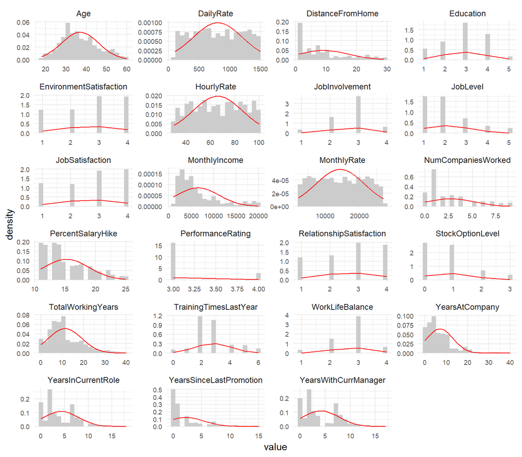

```r
#find group with statistical difference
colNum = names(which(sapply(data,is.numeric)))
#melging data so ggplot is happy
temp=reshape2::melt(data,id.vars='Attrition',measure.vars=colNum) %>%
  group_by(variable) %>%
  mutate(density = dnorm(value, mean(value), sd(value))) %>% ungroup()
#plotting
ggplot(data=temp,aes(x=value))+
  geom_histogram(aes(y=..density..),fill='#cccccc',bins = 20) +
  geom_line(aes(y = density),   colour = "red") +
  #stat_function(fun = dnorm, args = list(mean = mean(..count..), sd = sd(..count..)),color='red')+
  facet_wrap(~variable,scales='free',ncol=4) +
  theme_minimal() +
  theme(axis.text=element_text(size=7)
        ,strip.text=element_text(size=9)
        )
```

### Applying Log to Some Variables

Following Variable have been transformed with Log function to fit a normal distribution.

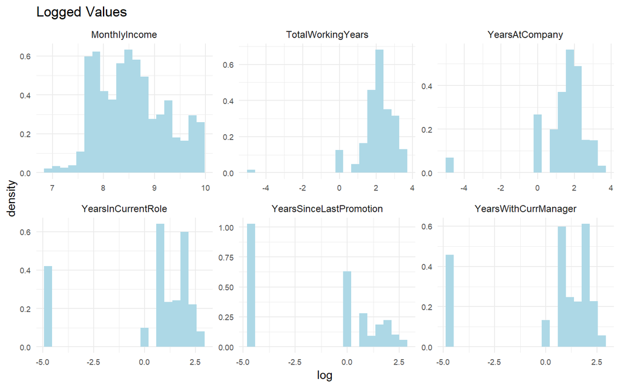

```r
#Testing the Log
colsToLog = c('MonthlyIncome','TotalWorkingYears','YearsAtCompany','YearsInCurrentRole','YearsSinceLastPromotion','YearsWithCurrManager')
temp$log = log(temp$value +.01)
#plot of logged values
ggplot(data=filter(temp,variable %in% colsToLog),aes(x=log))+
  geom_histogram(aes(y=..density..),fill='lightblue',bins = 20) +
  facet_wrap(~variable,scales='free',ncol=3) +
  ggplot2::ggtitle('Logged Values')+
  theme_minimal() +
  theme(axis.text=element_text(size=7)
        ,strip.text=element_text(size=9)
        )
```

```r
#Applying the log to the main dataframe
colsLog = paste0(colsToLog,'_log')
dataLog=mutate_at(data,colsToLog,.funs=funs(log=log(. + 0.01))) %>% select(-colsToLog)
```

### Columns with different mean across Attrition

Following variables have a statisticall significant difference mean between Attrition and Non-Attrition

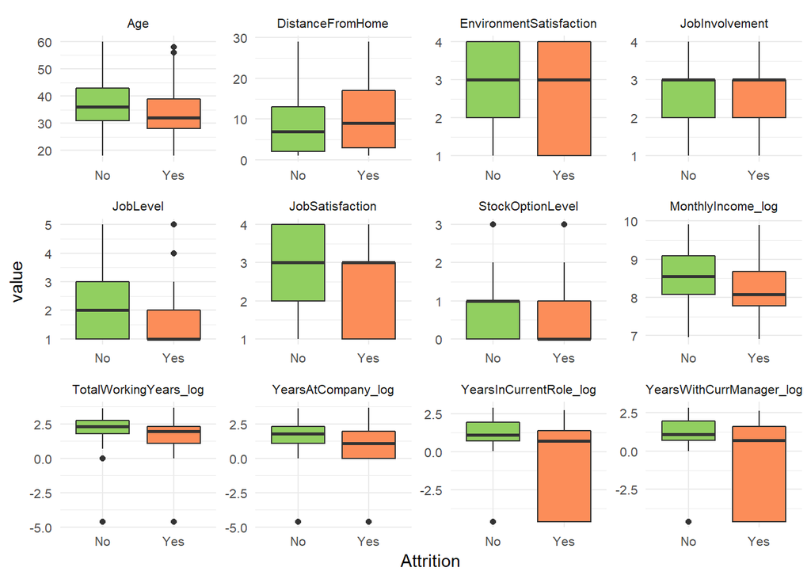

```r
ttestOut=data.frame(col=as.character(),pValue=as.numeric())
colNum = names(which(sapply(dataLog,is.numeric)))
#spanning the columns to checking the ones that fail the Ho
for (col in colNum){
  test=t.test(dataLog[dataLog$Attrition=='Yes',col],dataLog[dataLog$Attrition=='No',col]
              ,alternative = 'two.sided',var.equal=F)
  if(test$p.value<0.01) ttestOut = rbind(ttestOut,data.frame(col=col,pValue=test$p.value))
}
#melting and plotting
temp=reshape2::melt(dataLog,id.vars='Attrition',measure.vars=ttestOut$col)
ggplot(data=temp,aes(x=Attrition,y=value,fill=Attrition))+
  geom_boxplot() +
  facet_wrap(~variable,scales='free',ncol=4) +
  theme_minimal()  +
  scale_fill_manual(values=c('Yes'='#fc8d59','No'='#91cf60'),guide=F)+
  theme(axis.text=element_text(size=8)
        ,strip.text=element_text(size=8)
        )
```

**List of P-Values for selected variables**

```r
kable(arrange(ttestOut,-pValue),digits=4)
```

| col | pValue |
| --- | --- |
| DistanceFromHome | 0.0041 |
| EnvironmentSatisfaction | 0.0002 |
| JobSatisfaction | 0.0001 |
| JobInvolvement | 0.0000 |
| StockOptionLevel | 0.0000 |
| Age | 0.0000 |
| YearsAtCompany_log | 0.0000 |
| YearsInCurrentRole_log | 0.0000 |
| TotalWorkingYears_log | 0.0000 |
| YearsWithCurrManager_log | 0.0000 |
| JobLevel | 0.0000 |
| MonthlyIncome_log | 0.0000 |

## Categorical Variables

Distribution of the attrition across categorical values

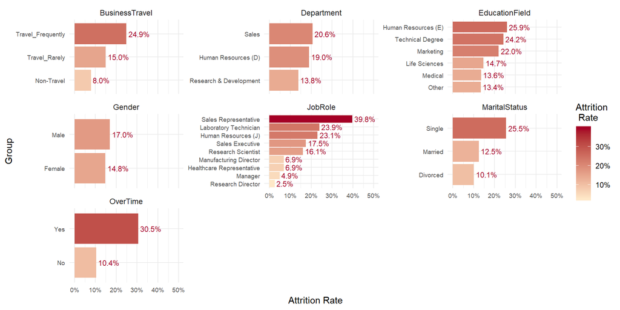

```r
#find group with statistical difference
colText = names(which(sapply(select(data,-Attrition,-EmployeeNumber),is.character)))

#make the datast vertical to better manage and chart. Also calculating percentages
temp=reshape2::melt(data,id.vars='Attrition',measure.vars=colText)  %>%
  group_by(variable,value,Attrition) %>%
  summarise(count=n()) %>%
  group_by(variable,value) %>%
  mutate(percent=count/sum(count) ) %>%
  filter(Attrition=='Yes') %>%
  arrange(percent)

#ggplot sort breaks if we have same value across facets.
#to help gplot sort we need to the value+variable insetead of value if there are more than one acorss variables
temp = temp %>% group_by(value)  %>% mutate(cnt = n_distinct(variable)) %>%
  ungroup() %>% mutate(name=ifelse(cnt>1,paste0(value,' (',(substr(variable,1,1)),')'),value))

temp$name=forcats::fct_reorder(temp$name,temp$percent )

ggplot(data=temp,aes(x=name,y=percent,fill=percent))+
  geom_bar(stat='identity') +
  coord_flip()+
  geom_text(aes(label=percent(percent)),size=3,hjust=-.1,color='#a50026')+
  facet_wrap(~variable,scales='free_y',ncol=3) +
  ggplot2::scale_y_continuous(labels=percent_format(accuracy = 1)
                              ,limits=c(0,max(temp$percent+.1))
                              ,name='Attrition Rate') +
  ggplot2::scale_x_discrete(name='Group') +
  scale_fill_gradient(low='#fee8c8',high='#a50026',name='Attrition \n Rate',labels=percent_format(accuracy=1))+
  theme_minimal()+
  theme(axis.text=element_text(size=7)
        ,strip.text=element_text(size=9)
        )
```

# Three Leading Attrition Factors

*Identify (at least) the top three factors that contribute to turnover.*

## Money Related Factors

### Attrition and Monthly Income

People leaving the company have lower salary.

```
## which will replace the existing scale.
```

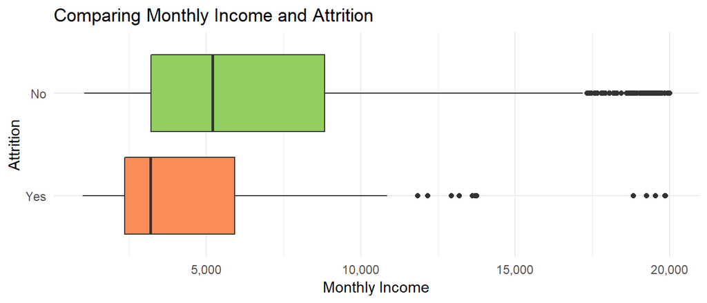

```r
plotTrend(data,'Attrition','MonthlyIncome') +
  scale_fill_manual(values=c('Yes'='#fc8d59','No'='#91cf60'),guide=F)
```

### Experience and Income

Controlling for “Working Years”, people leaving the company still have lower salary

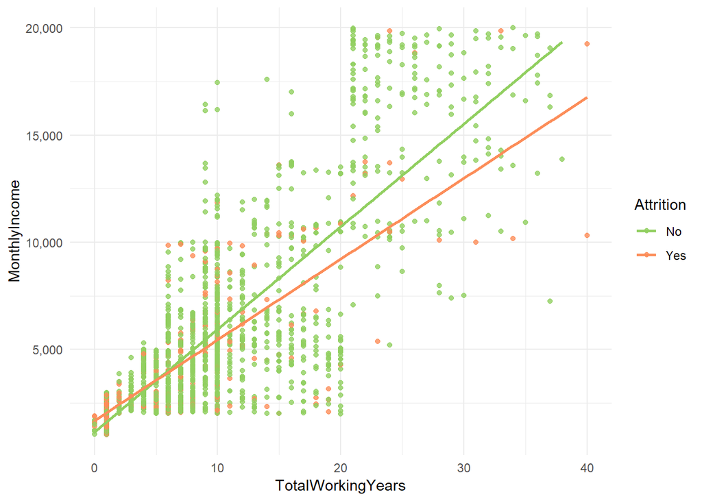

```r
ggplot(data = data, aes(x = TotalWorkingYears, y = MonthlyIncome, colour = Attrition)) +
  geom_point(alpha=0.8) +
  geom_smooth(method = 'lm', se = FALSE) +
  theme_minimal() +
  scale_y_continuous(label=comma_format()) +
  scale_color_manual(values=c('Yes'='#fc8d59','No'='#91cf60'))
```

### Stock Options

- People leaving the company have lower stock options (as expected).
- Surprising to see employees with Stock Option level = 3 leaving at a higher rate.

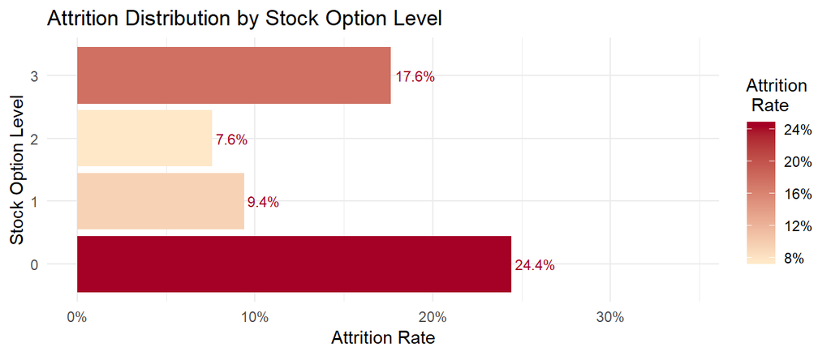

```r
plotAttritionBars(data,'StockOptionLevel',sort=F)
```

## Age and Tenure

### Age and Attrition

Younger people tend to leave the compan

```
## which will replace the existing scale.
```

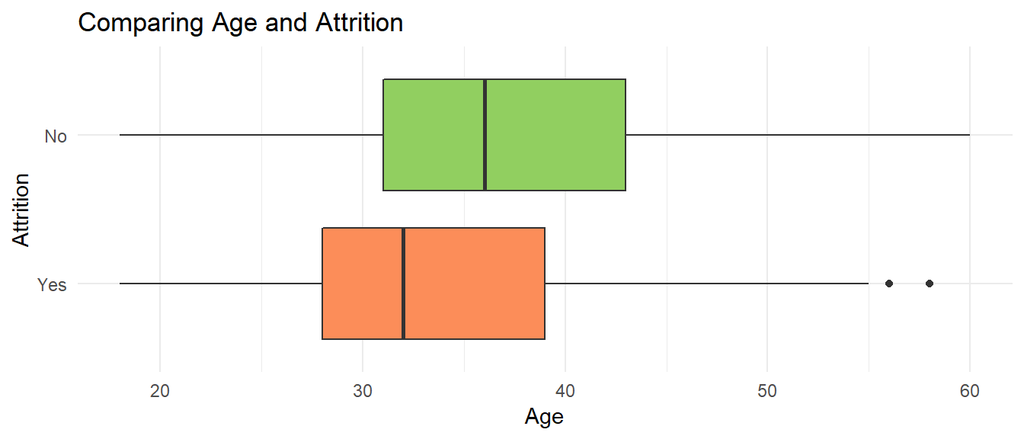

```r
plotTrend(data,'Attrition','Age')  +  scale_fill_manual(values=c('Yes'='#fc8d59','No'='#91cf60'),guide=F)
```

### Marital Status

Single employees have greater flexibility which could contribute to higher attrition

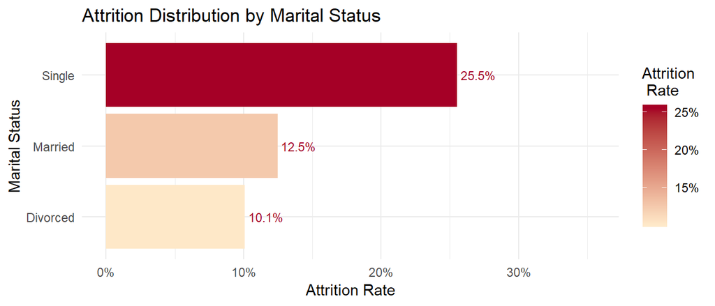

```r
plotAttritionBars(data,'MaritalStatus')
```

### Years at Company

- People with lower tenure have higher attrition.
- This is also true when considering Current Manager and the Current Role

```
## which will replace the existing scale.
```

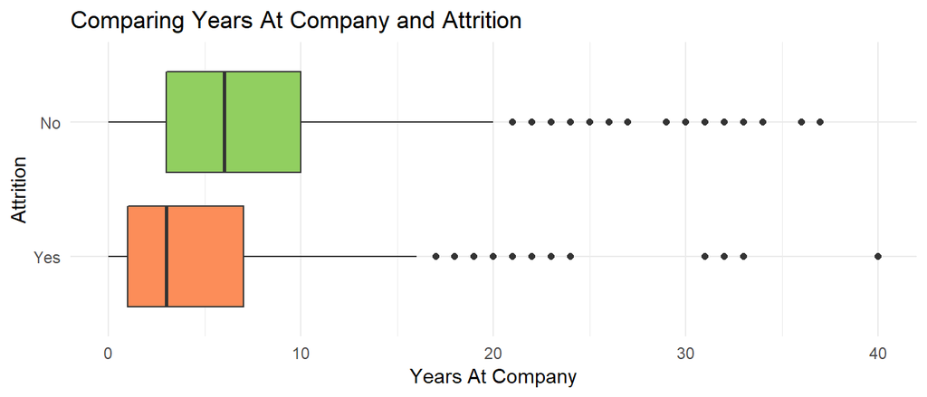

```r
plotTrend(data,'Attrition','YearsAtCompany')  +  scale_fill_manual(values=c('Yes'='#fc8d59','No'='#91cf60'),guide=F)
```

```
## which will replace the existing scale.
```

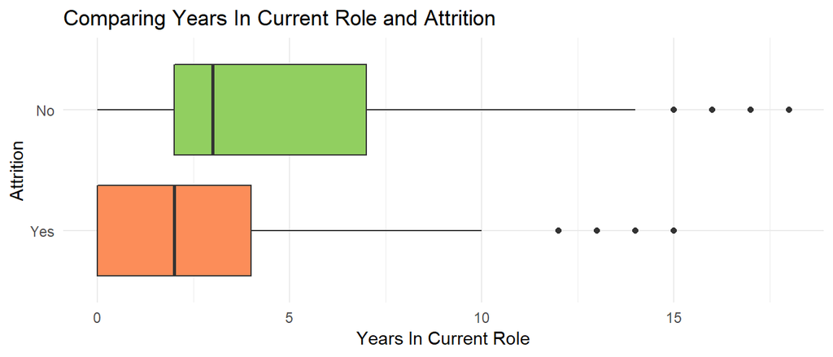

```r
plotTrend(data,'Attrition','YearsInCurrentRole')  +  scale_fill_manual(values=c('Yes'='#fc8d59','No'='#91cf60'),guide=F)
```

```
## which will replace the existing scale.
```

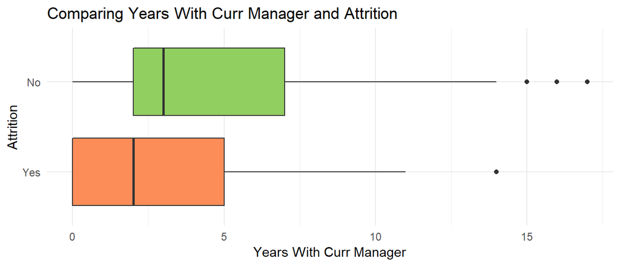

```r
plotTrend(data,'Attrition','YearsWithCurrManager')  +  scale_fill_manual(values=c('Yes'='#fc8d59','No'='#91cf60'),guide=F)
```

## Instrinsic Factors

### Job Involvment

- Again, employees who are less involved in their jobs are more likely to leave

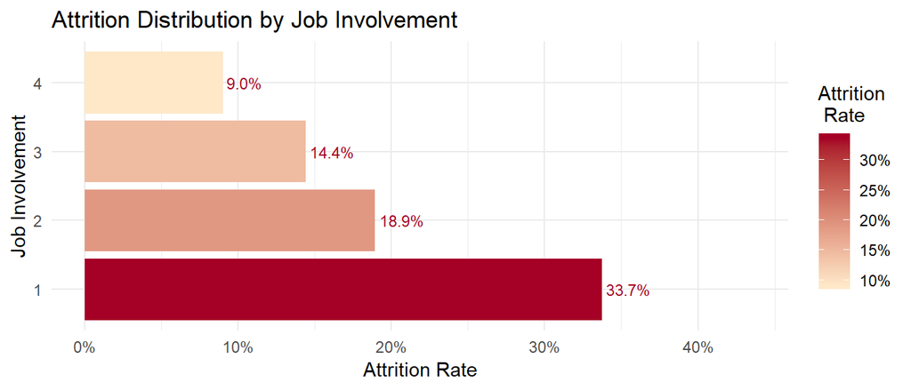

```r
plotAttritionBars(data,'JobInvolvement',sort=F)
```

### Job Satisfaction

No surprises here… more attrition for less satisfied employees

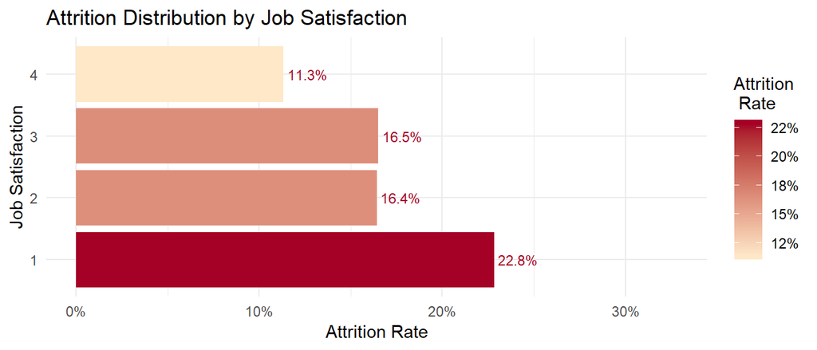

```r
plotAttritionBars(data,'JobSatisfaction',sort=F)
```

### Environment Satisfaction

Again, employees who are less satisfied with the environment are more likely to leave.

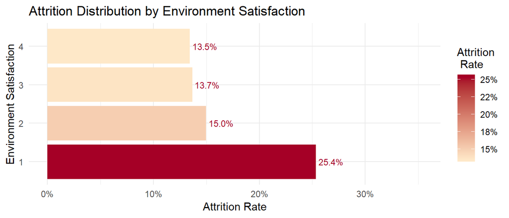

```r
plotAttritionBars(data,'EnvironmentSatisfaction',sort=F)
```

### Overtime

Employees who do overtime leave at a rate that is 3X higher than those who don’t do overtime Burnout could be a factor

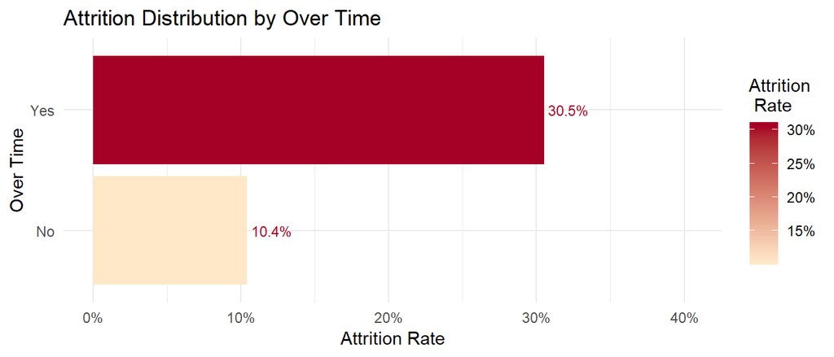

```r
plotAttritionBars(data,'OverTime',sort=F)
```

### Conclusion

- Factor 1: Money
  - Lower income leads to higher attrition
- Factor 2: Age
  - Younger employees are more flexible (single) and less likely to be tied to a job
- Factor 3: Intrinsic
  - Low job involvement, satisfaction, and overtime leads to higher attrition

### Action Plan

- Money Related:
  - Recommend skewing compensation towards higher performing employees
- Age and Tenure related
  - Recommend giving long vesting period stocks to critical young employees
  - Dig deeper into why employees with Stock level = 3 are leaving (is it competitive?)
- Intrinsic Factors
  - Recommend developing mentoring programs to increase job involvement.
  - Stress and burnout mitigation program for overtime employees

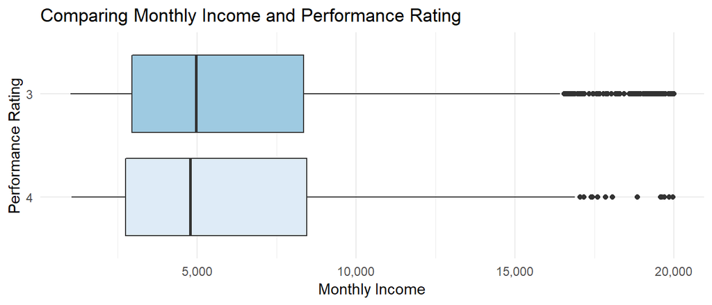

```r
data$AgeCut = cut(data$Age,breaks=c(0,35,60))
plotTrend(data,'PerformanceRating','MonthlyIncome')
```

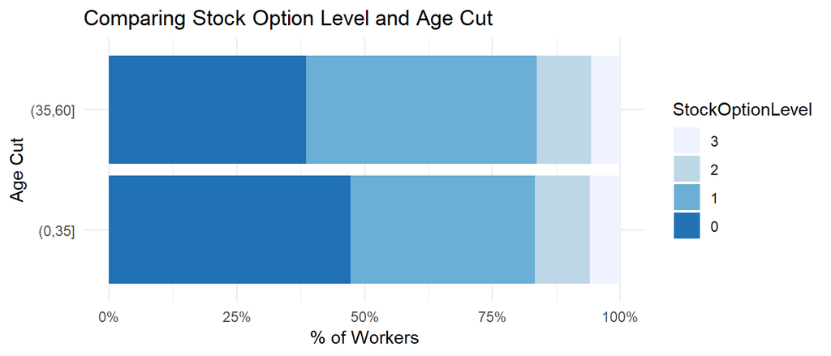

```r
plotBars(data,'AgeCut','StockOptionLevel')
```

# Job Specific Insights

## Lab Technicians vs. Research Scientists

Lab technicians had 50% more chance of leaving

```r
plotAttritionBars(data,'JobRole')
```

[output not shown]

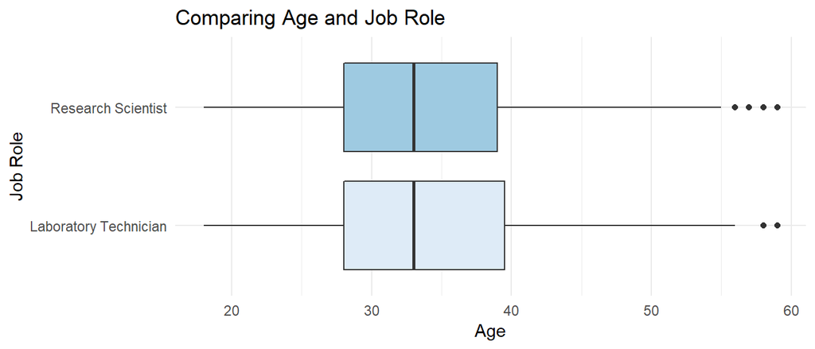

```r
dataLabRes = filter(data,JobRole %in% c('Research Scientist','Laboratory Technician'))
plotTrend(dataLabRes,'JobRole','Age')
```

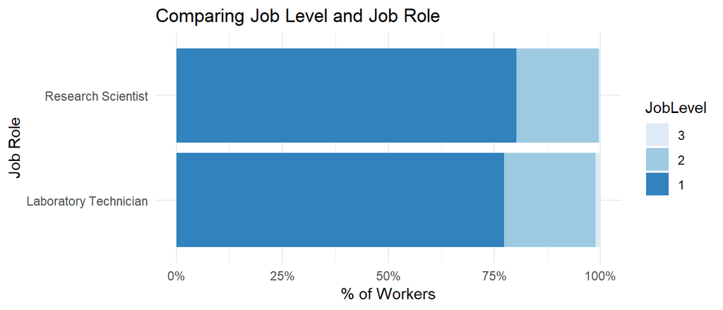

```r
plotBars(dataLabRes,'JobRole','JobLevel')
```

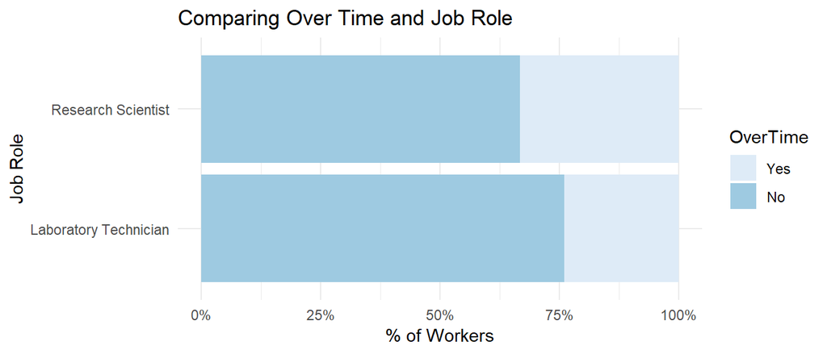

```r
plotBars(dataLabRes,'JobRole','OverTime')
```

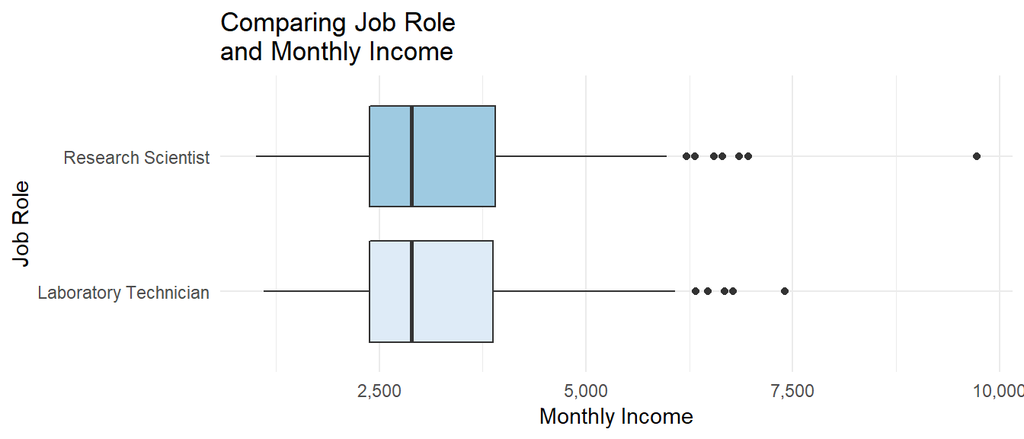

```r
plotTrend(dataLabRes,'JobRole','MonthlyIncome',title='Comparing Job Role \nand Monthly Income')
```

## Human Resources

Least satisfied in general

Why? Explore

- People Aspect
- Environment

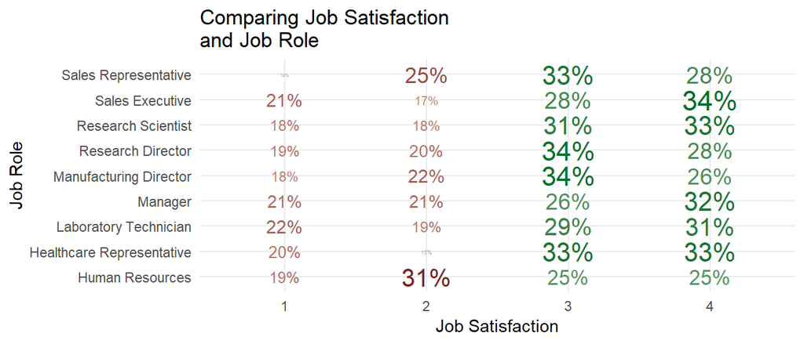

```r
plotSurvey(data,'JobRole','JobSatisfaction')
```

```r
plotAttritionBars(data,'JobRole')
```

[output not shown]

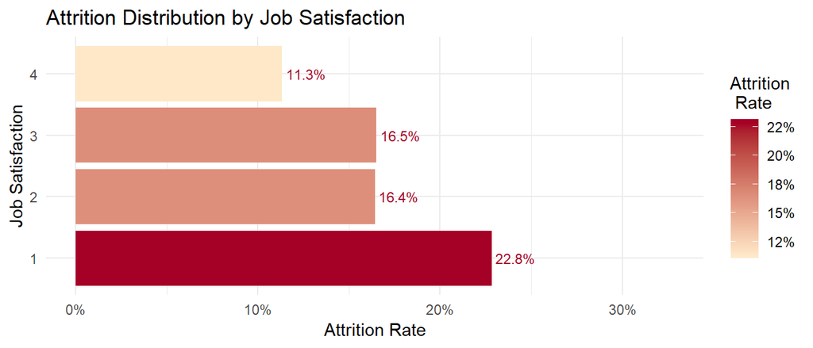

```r
plotAttritionBars(data,'JobSatisfaction',sort=F)
```

## Sales Reps

- Highest Attrition
- Not necessarily related to travel
- Possibly related to younger population

```r
plotAttritionBars(data,'JobRole')
```

[output not shown]

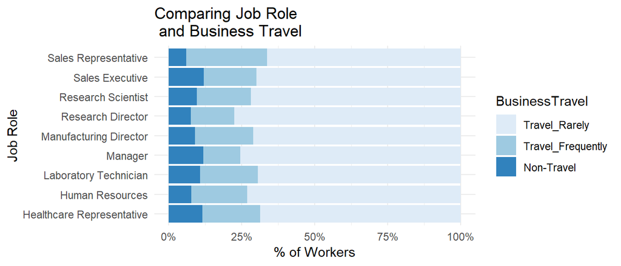

```r
plotBars(data,'JobRole','BusinessTravel',title='Comparing Job Role \n and Business Travel')
```

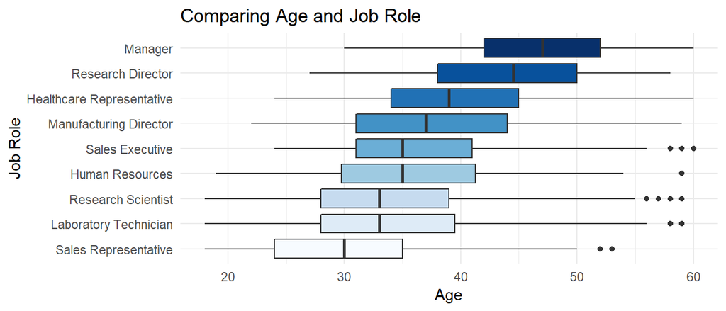

```r
plotTrend(data,'JobRole','Age')
```

## Summary

- Lab Technician vs. Research Scientist
  - No obvious reason for higher attrition. More root cause analysis needed.
- Human Resources have high attrition
  - Likely correlated to lower job satisfaction
- Sales Rep have highest attrition
  - Likely correlated to younger age distribution.